# OJ

## Visualizing the quantity/price relationship

Plot logmove (log quantity) vs. log(price) for each brand.

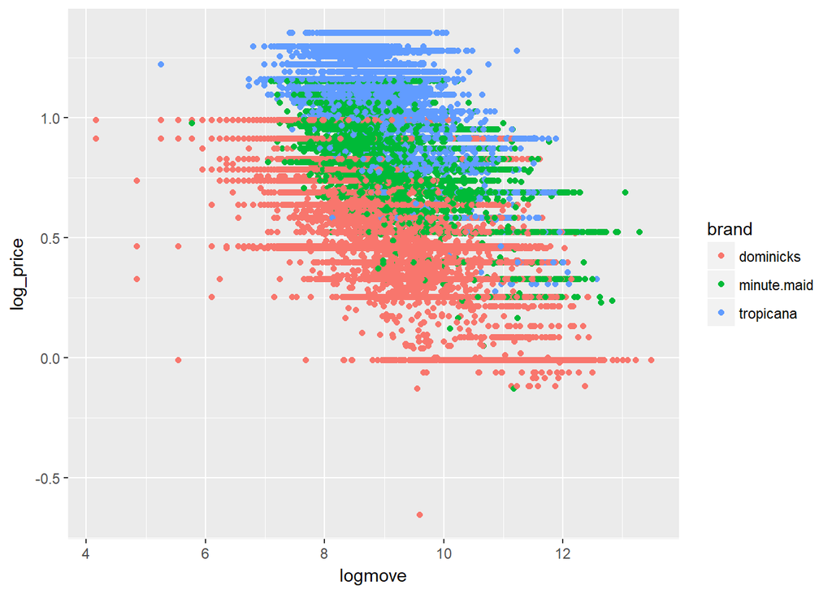

```r
oj %>%
  mutate(log_price = log(price)) %>%
  ggplot(aes(x = logmove, y = log_price)) +
  geom_point(aes(color = brand))
```

## Estimating the relationship

Do a regression of log quantity on log price.

```r
regression <- oj %>%
  lm(formula = logmove ~ log_price)

summary(regression)
```

```
##
## Call:
## lm(formula = logmove ~ log_price, data = .)
##
## Residuals:
##     Min      1Q  Median      3Q     Max
## -5.0441 -0.5853 -0.0330  0.5756  3.7264
##
## Coefficients:
##             Estimate Std. Error t value Pr(>|t|)
## (Intercept) 10.42342    0.01535  679.04   <2e-16 ***
## log_price   -1.60131    0.01836  -87.22   <2e-16 ***
## ---
## Signif. codes:  0 '***' 0.001 '**' 0.01 '*' 0.05 '.' 0.1 ' ' 1
##
## Residual standard error: 0.9071 on 28945 degrees of freedom
## Multiple R-squared:  0.2081, Adjusted R-squared:  0.2081
## F-statistic:  7608 on 1 and 28945 DF,  p-value: < 2.2e-16
```

#### How well does the model fit? What is the elasticity, does it make sense?

R-squared is small => doesn’t explain variance well, so the model is not a great fit.

Now add in an intercept term for each brand (add brand to the regression), how do the results change?

```r
regression_with_intercept <- oj %>%
  lm(formula = logmove ~ log_price + brand)

summary(regression_with_intercept)
```

```
##
## Call:
## lm(formula = logmove ~ log_price + brand, data = .)
##
## Residuals:
##     Min      1Q  Median      3Q     Max
## -5.3152 -0.5246 -0.0502  0.4929  3.5088
##
## Coefficients:
##                  Estimate Std. Error t value Pr(>|t|)
## (Intercept)      10.82882    0.01453  745.04   <2e-16 ***
## log_price        -3.13869    0.02293 -136.89   <2e-16 ***
## brandminute.maid  0.87017    0.01293   67.32   <2e-16 ***
## brandtropicana    1.52994    0.01631   93.81   <2e-16 ***
## ---
## Signif. codes:  0 '***' 0.001 '**' 0.01 '*' 0.05 '.' 0.1 ' ' 1
##
## Residual standard error: 0.7935 on 28943 degrees of freedom
## Multiple R-squared:  0.3941, Adjusted R-squared:  0.394
## F-statistic:  6275 on 3 and 28943 DF,  p-value: < 2.2e-16
```

Now figure out a way to allow the elasticities to differ by brand. Search “interaction terms” and “dummy variables” if you don’t remember this from econometrics. Note the estimate coefficients will “offset” the base estimates. What is the insights we get from this regression? What is the elasticity for each firm? Do the elasticities make sense?

```r
regression_with_interaction <- oj %>%
  lm(formula = logmove ~ log_price * brand)

summary(regression_with_interaction)
```

```
##
## Call:
## lm(formula = logmove ~ log_price * brand, data = .)
##
## Residuals:
##     Min      1Q  Median      3Q     Max
## -5.4434 -0.5232 -0.0494  0.4884  3.4901
##
## Coefficients:
##                            Estimate Std. Error t value Pr(>|t|)
## (Intercept)                10.95468    0.02070 529.136   <2e-16 ***
## log_price                  -3.37753    0.03619 -93.322   <2e-16 ***
## brandminute.maid            0.88825    0.04155  21.376   <2e-16 ***
## brandtropicana              0.96239    0.04645  20.719   <2e-16 ***
## log_price:brandminute.maid  0.05679    0.05729   0.991    0.322
## log_price:brandtropicana    0.66576    0.05352  12.439   <2e-16 ***
## ---
## Signif. codes:  0 '***' 0.001 '**' 0.01 '*' 0.05 '.' 0.1 ' ' 1
##
## Residual standard error: 0.7911 on 28941 degrees of freedom
## Multiple R-squared:  0.3978, Adjusted R-squared:  0.3977
## F-statistic:  3823 on 5 and 28941 DF,  p-value: < 2.2e-16
```

```r
# plot(logmove ~ log_price, data = oj)
# abline(regression, col = "blue")
# abline(regression_with_intercept, col = "darkgreen")
# abline(regression_with_interaction, col = "red")
```

Hold out 20% of your sample randomly. Estimate the model on the remaining 80%. Use the predict command to see how well the model fits on the rest of the data (e.g., y_hat <- predict(my_model, newx = test_matrix))

```r
idx <- as.integer((nrow(oj)*0.8))

set.seed(42)
train_idx <- sample(seq_len(nrow(oj)), idx)

train <- data.frame(oj[train_idx,])
test <- data.frame(oj[-train_idx,])

model <- lm(formula = logmove ~ log_price + brand + log_price*brand, data = oj)

y_hat <- predict(model, newx = test)
summary(y_hat)
```

```
##    Min. 1st Qu.  Median    Mean 3rd Qu.    Max.
##   7.612   8.751   9.164   9.168   9.558  13.163
```

## Impact of “featuring in store”

Which brand is featured the most?

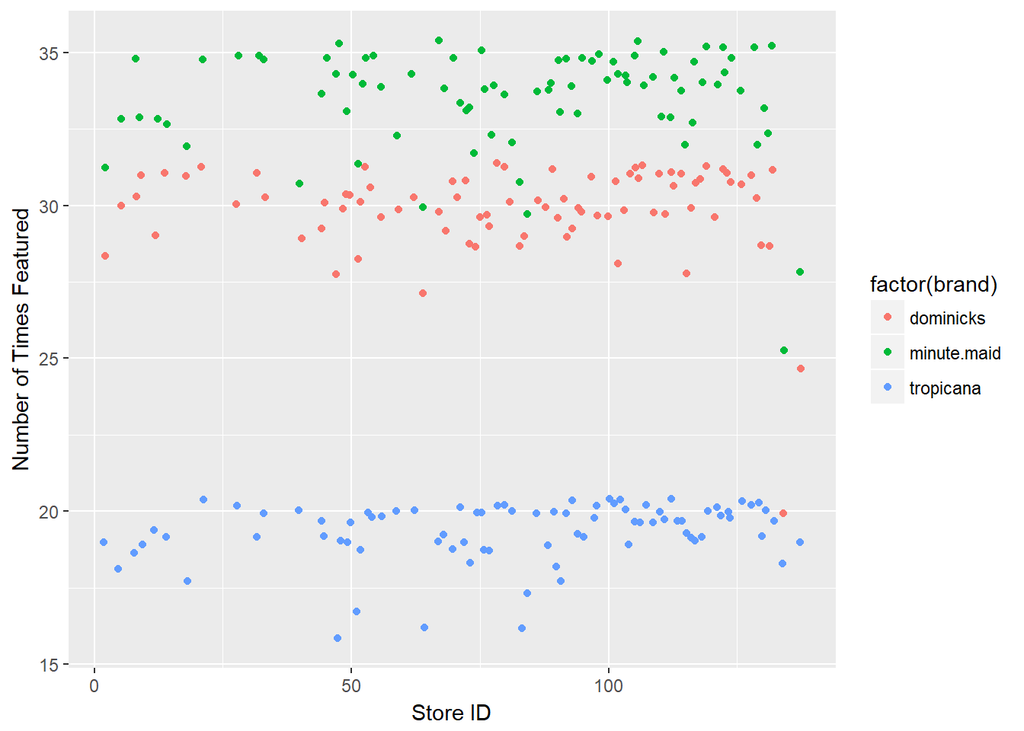

```r
oj %>%
  group_by(store, brand, feat) %>% summarize(count= n()) %>% filter(feat == 1) %>%
  ggplot(aes(x = store, y = count)) +
  geom_point(aes(color = factor(brand)), position = "jitter") +
  xlab("Store ID") +
  ylab("Number of Times Featured")
```

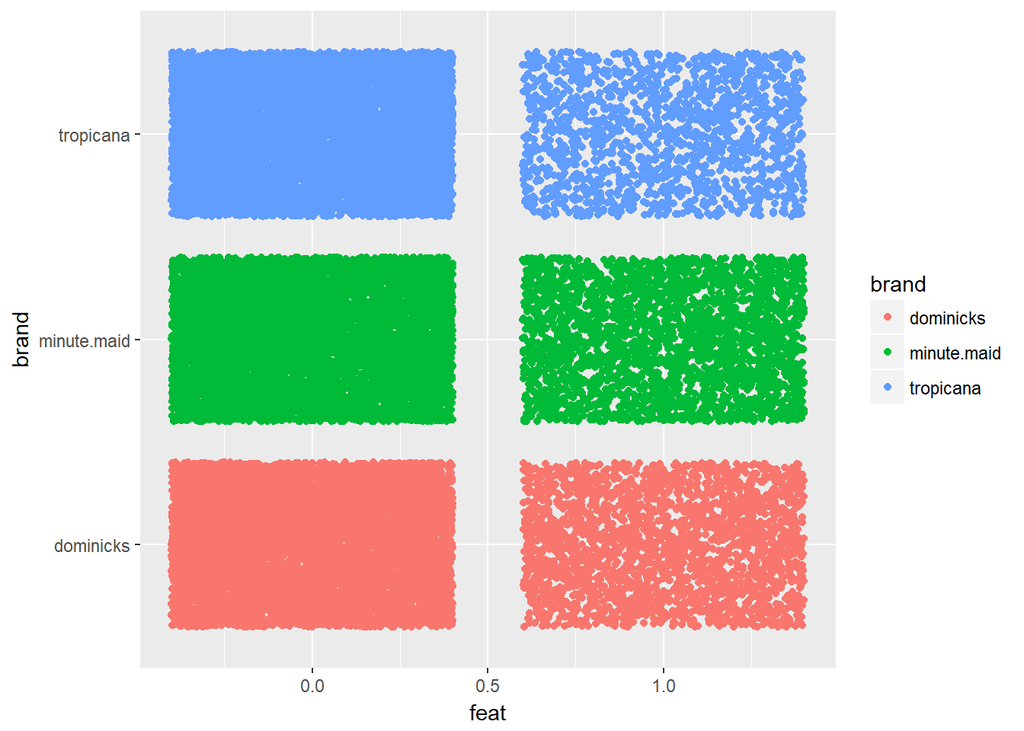

```r
oj %>%
  ggplot(aes(feat, brand)) +
  geom_point(position = "jitter", aes(color = brand))
```

What is the average price and featured rate of each brand?

```r
oj %>%
  group_by(brand) %>%
  summarize(feat = mean(feat), price = mean(price))
```

```
## # A tibble: 3 x 3
##   brand        feat price
##   <fct>       <dbl> <dbl>
## 1 dominicks   0.257  1.74
## 2 minute.maid 0.289  2.24
## 3 tropicana   0.166  2.87
```

```r
oj %>%
  group_by(brand, feat) %>%
  summarize(mean_price = mean(price), sd_price = sd(price), obs = length(price))
```

```
## # A tibble: 6 x 5
## # Groups:   brand [?]
##   brand        feat mean_price sd_price   obs
##   <fct>       <int>      <dbl>    <dbl> <int>
## 1 dominicks       0       1.80    0.382  7169
## 2 dominicks       1       1.56    0.342  2480
## 3 minute.maid     0       2.33    0.408  6865
## 4 minute.maid     1       2.02    0.301  2784
## 5 tropicana       0       2.97    0.513  8045
## 6 tropicana       1       2.39    0.461  1604
```

How should incorporate the feature variable into our regression? Start with an additive formulation (e.g. feature impacts sales, but not through price).

```r
regression_with_feature <- oj %>%
  lm(formula = logmove ~ log_price * brand + feat)

summary(regression_with_feature)
```

```
##
## Call:
## lm(formula = logmove ~ log_price * brand + feat, data = .)
##
## Residuals:
##     Min      1Q  Median      3Q     Max
## -4.9524 -0.4408 -0.0036  0.4231  3.2363
##
## Coefficients:
##                            Estimate Std. Error t value Pr(>|t|)
## (Intercept)                10.46852    0.01932 541.843  < 2e-16 ***
## log_price                  -2.89261    0.03279 -88.227  < 2e-16 ***
## brandminute.maid            0.51271    0.03734  13.732  < 2e-16 ***
## brandtropicana              0.62865    0.04163  15.100  < 2e-16 ***
## feat                        0.89728    0.01043  86.029  < 2e-16 ***
## log_price:brandminute.maid  0.33426    0.05123   6.525 6.92e-11 ***
## log_price:brandtropicana    0.82914    0.04780  17.346  < 2e-16 ***
## ---
## Signif. codes:  0 '***' 0.001 '**' 0.01 '*' 0.05 '.' 0.1 ' ' 1
##
## Residual standard error: 0.706 on 28940 degrees of freedom
## Multiple R-squared:  0.5204, Adjusted R-squared:  0.5203
## F-statistic:  5234 on 6 and 28940 DF,  p-value: < 2.2e-16
```

Now run a model where features can impact sales and price sensitivity.

```r
regression_with_feature_price <- oj %>%
  lm(formula = logmove ~ log_price * brand + feat * log_price)

summary(regression_with_feature_price)
```

```
##
## Call:
## lm(formula = logmove ~ log_price * brand + feat * log_price,
##     data = .)
##
## Residuals:
##     Min      1Q  Median      3Q     Max
## -4.7488 -0.4398 -0.0128  0.4144  3.2861
##
## Coefficients:
##                            Estimate Std. Error t value Pr(>|t|)
## (Intercept)                10.26784    0.02184 470.047  < 2e-16 ***
## log_price                  -2.60187    0.03591 -72.461  < 2e-16 ***
## brandminute.maid            0.60591    0.03742  16.194  < 2e-16 ***
## brandtropicana              0.84241    0.04283  19.668  < 2e-16 ***
## feat                        1.40000    0.02809  49.841  < 2e-16 ***
## log_price:brandminute.maid  0.18644    0.05148   3.622 0.000293 ***
## log_price:brandtropicana    0.54811    0.04969  11.031  < 2e-16 ***
## log_price:feat             -0.75214    0.03906 -19.256  < 2e-16 ***
## ---
## Signif. codes:  0 '***' 0.001 '**' 0.01 '*' 0.05 '.' 0.1 ' ' 1
##
## Residual standard error: 0.7015 on 28939 degrees of freedom
## Multiple R-squared:  0.5265, Adjusted R-squared:  0.5264
## F-statistic:  4597 on 7 and 28939 DF,  p-value: < 2.2e-16
```

Now add what you think are the most relevant sociodemographic controls and produce the regression results from that regression as well.

```r
regression_with_socio <- oj %>%
  lm(formula = logmove ~ log_price * brand + feat * log_price + AGE60)

summary(regression_with_socio)
```

```
##
## Call:
## lm(formula = logmove ~ log_price * brand + feat * log_price +
##     AGE60, data = .)
##
## Residuals:
##     Min      1Q  Median      3Q     Max
## -4.7833 -0.4317 -0.0136  0.4097  3.2119
##
## Coefficients:
##                            Estimate Std. Error t value Pr(>|t|)
## (Intercept)                 9.95187    0.02409 413.074  < 2e-16 ***
## log_price                  -2.62979    0.03540 -74.283  < 2e-16 ***
## brandminute.maid            0.62587    0.03688  16.969  < 2e-16 ***
## brandtropicana              0.86615    0.04222  20.514  < 2e-16 ***
## feat                        1.38680    0.02769  50.087  < 2e-16 ***
## AGE60                       1.92247    0.06579  29.222  < 2e-16 ***
## log_price:brandminute.maid  0.16971    0.05074   3.345 0.000825 ***
## log_price:brandtropicana    0.53733    0.04897  10.972  < 2e-16 ***
## log_price:feat             -0.74065    0.03850 -19.238  < 2e-16 ***
## ---
## Signif. codes:  0 '***' 0.001 '**' 0.01 '*' 0.05 '.' 0.1 ' ' 1
##
## Residual standard error: 0.6914 on 28938 degrees of freedom
## Multiple R-squared:  0.5401, Adjusted R-squared:  0.5399
## F-statistic:  4248 on 8 and 28938 DF,  p-value: < 2.2e-16
```

```r
### R-squared = 0.5401
```